# Risk Factor Analysis

## Outcome Variable

**Outcome Variable:** stunted

## Predictor Variables

**Intervention Variable:** feducyrs

**Adjustment Set:**

unadjusted

## Stratifying Variables

The analysis was stratified on these variable(s):

- agecat
- studyid
- country

## Data Summary

| agecat | studyid | country | A | n | nA | nAY0 | nAY1 |
| --- | --- | --- | --- | --- | --- | --- | --- |
| Birth | ki0047075b-MAL-ED | BANGLADESH | Q4 | 144 | 52 | 44 | 8 |
| Birth | ki0047075b-MAL-ED | BANGLADESH | Q1 | 144 | 29 | 24 | 5 |
| Birth | ki0047075b-MAL-ED | BANGLADESH | Q2 | 144 | 9 | 6 | 3 |
| Birth | ki0047075b-MAL-ED | BANGLADESH | Q3 | 144 | 54 | 44 | 10 |
| Birth | ki0047075b-MAL-ED | INDIA | Q4 | 123 | 38 | 32 | 6 |
| Birth | ki0047075b-MAL-ED | INDIA | Q1 | 123 | 21 | 20 | 1 |
| Birth | ki0047075b-MAL-ED | INDIA | Q2 | 123 | 37 | 33 | 4 |
| Birth | ki0047075b-MAL-ED | INDIA | Q3 | 123 | 27 | 23 | 4 |
| Birth | ki0047075b-MAL-ED | NEPAL | Q4 | 67 | 27 | 26 | 1 |
| Birth | ki0047075b-MAL-ED | NEPAL | Q1 | 67 | 18 | 16 | 2 |
| Birth | ki0047075b-MAL-ED | NEPAL | Q2 | 67 | 17 | 13 | 4 |
| Birth | ki0047075b-MAL-ED | NEPAL | Q3 | 67 | 5 | 4 | 1 |
| Birth | ki0047075b-MAL-ED | PERU | Q4 | 236 | 116 | 106 | 10 |
| Birth | ki0047075b-MAL-ED | PERU | Q1 | 236 | 47 | 37 | 10 |
| Birth | ki0047075b-MAL-ED | PERU | Q2 | 236 | 62 | 56 | 6 |
| Birth | ki0047075b-MAL-ED | PERU | Q3 | 236 | 11 | 11 | 0 |
| Birth | ki0047075b-MAL-ED | SOUTH AFRICA | Q4 | 91 | 35 | 30 | 5 |
| Birth | ki0047075b-MAL-ED | SOUTH AFRICA | Q1 | 91 | 15 | 15 | 0 |
| Birth | ki0047075b-MAL-ED | SOUTH AFRICA | Q2 | 91 | 22 | 22 | 0 |
| Birth | ki0047075b-MAL-ED | SOUTH AFRICA | Q3 | 91 | 19 | 16 | 3 |
| Birth | ki0047075b-MAL-ED | TANZANIA, UNITED REPUBLIC OF | Q4 | 101 | 3 | 3 | 0 |
| Birth | ki0047075b-MAL-ED | TANZANIA, UNITED REPUBLIC OF | Q1 | 101 | 20 | 18 | 2 |
| Birth | ki0047075b-MAL-ED | TANZANIA, UNITED REPUBLIC OF | Q2 | 101 | 16 | 11 | 5 |
| Birth | ki0047075b-MAL-ED | TANZANIA, UNITED REPUBLIC OF | Q3 | 101 | 62 | 54 | 8 |
| Birth | ki1017093c-NIH-Crypto | BANGLADESH | Q4 | 27 | 5 | 5 | 0 |
| Birth | ki1017093c-NIH-Crypto | BANGLADESH | Q1 | 27 | 4 | 3 | 1 |
| Birth | ki1017093c-NIH-Crypto | BANGLADESH | Q2 | 27 | 11 | 9 | 2 |
| Birth | ki1017093c-NIH-Crypto | BANGLADESH | Q3 | 27 | 7 | 5 | 2 |
| Birth | ki1126311-ZVITAMBO | ZIMBABWE | Q4 | 13460 | 11504 | 10338 | 1166 |
| Birth | ki1126311-ZVITAMBO | ZIMBABWE | Q1 | 13460 | 82 | 74 | 8 |

[output cut: 386 more lines]

The following strata were considered:

- agecat: 12 months, studyid: ki0047075b-MAL-ED, country: BANGLADESH
- agecat: 12 months, studyid: ki0047075b-MAL-ED, country: INDIA
- agecat: 12 months, studyid: ki0047075b-MAL-ED, country: NEPAL
- agecat: 12 months, studyid: ki0047075b-MAL-ED, country: PERU
- agecat: 12 months, studyid: ki0047075b-MAL-ED, country: SOUTH AFRICA
- agecat: 12 months, studyid: ki0047075b-MAL-ED, country: TANZANIA, UNITED REPUBLIC OF
- agecat: 12 months, studyid: ki1000304b-SAS-FoodSuppl, country: INDIA
- agecat: 12 months, studyid: ki1017093b-PROVIDE, country: BANGLADESH
- agecat: 12 months, studyid: ki1017093c-NIH-Crypto, country: BANGLADESH
- agecat: 12 months, studyid: ki1066203-TanzaniaChild2, country: TANZANIA, UNITED REPUBLIC OF
- agecat: 12 months, studyid: ki1113344-GMS-Nepal, country: NEPAL
- agecat: 12 months, studyid: ki1126311-ZVITAMBO, country: ZIMBABWE
- agecat: 12 months, studyid: ki1135781-COHORTS, country: GUATEMALA
- agecat: 12 months, studyid: ki1135781-COHORTS, country: INDIA
- agecat: 12 months, studyid: ki1135781-COHORTS, country: PHILIPPINES
- agecat: 12 months, studyid: ki1148112-LCNI-5, country: MALAWI
- agecat: 18 months, studyid: ki0047075b-MAL-ED, country: BANGLADESH
- agecat: 18 months, studyid: ki0047075b-MAL-ED, country: INDIA
- agecat: 18 months, studyid: ki0047075b-MAL-ED, country: NEPAL
- agecat: 18 months, studyid: ki0047075b-MAL-ED, country: PERU
- agecat: 18 months, studyid: ki0047075b-MAL-ED, country: SOUTH AFRICA
- agecat: 18 months, studyid: ki0047075b-MAL-ED, country: TANZANIA, UNITED REPUBLIC OF
- agecat: 18 months, studyid: ki1000304b-SAS-FoodSuppl, country: INDIA
- agecat: 18 months, studyid: ki1017093b-PROVIDE, country: BANGLADESH
- agecat: 18 months, studyid: ki1017093c-NIH-Crypto, country: BANGLADESH
- agecat: 18 months, studyid: ki1066203-TanzaniaChild2, country: TANZANIA, UNITED REPUBLIC OF
- agecat: 18 months, studyid: ki1113344-GMS-Nepal, country: NEPAL
- agecat: 18 months, studyid: ki1126311-ZVITAMBO, country: ZIMBABWE
- agecat: 18 months, studyid: ki1135781-COHORTS, country: GUATEMALA
- agecat: 18 months, studyid: ki1135781-COHORTS, country: PHILIPPINES
- agecat: 18 months, studyid: ki1148112-LCNI-5, country: MALAWI
- agecat: 24 months, studyid: ki0047075b-MAL-ED, country: BANGLADESH
- agecat: 24 months, studyid: ki0047075b-MAL-ED, country: INDIA
- agecat: 24 months, studyid: ki0047075b-MAL-ED, country: NEPAL
- agecat: 24 months, studyid: ki0047075b-MAL-ED, country: PERU
- agecat: 24 months, studyid: ki0047075b-MAL-ED, country: SOUTH AFRICA
- agecat: 24 months, studyid: ki0047075b-MAL-ED, country: TANZANIA, UNITED REPUBLIC OF
- agecat: 24 months, studyid: ki1017093b-PROVIDE, country: BANGLADESH
- agecat: 24 months, studyid: ki1017093c-NIH-Crypto, country: BANGLADESH
- agecat: 24 months, studyid: ki1066203-TanzaniaChild2, country: TANZANIA, UNITED REPUBLIC OF
- agecat: 24 months, studyid: ki1113344-GMS-Nepal, country: NEPAL
- agecat: 24 months, studyid: ki1126311-ZVITAMBO, country: ZIMBABWE
- agecat: 24 months, studyid: ki1135781-COHORTS, country: GUATEMALA
- agecat: 24 months, studyid: ki1135781-COHORTS, country: INDIA
- agecat: 24 months, studyid: ki1135781-COHORTS, country: PHILIPPINES
- agecat: 24 months, studyid: ki1148112-LCNI-5, country: MALAWI
- agecat: 3 months, studyid: ki0047075b-MAL-ED, country: BANGLADESH
- agecat: 3 months, studyid: ki0047075b-MAL-ED, country: INDIA
- agecat: 3 months, studyid: ki0047075b-MAL-ED, country: NEPAL
- agecat: 3 months, studyid: ki0047075b-MAL-ED, country: PERU
- agecat: 3 months, studyid: ki0047075b-MAL-ED, country: SOUTH AFRICA
- agecat: 3 months, studyid: ki0047075b-MAL-ED, country: TANZANIA, UNITED REPUBLIC OF
- agecat: 3 months, studyid: ki1000304b-SAS-FoodSuppl, country: INDIA
- agecat: 3 months, studyid: ki1017093b-PROVIDE, country: BANGLADESH
- agecat: 3 months, studyid: ki1017093c-NIH-Crypto, country: BANGLADESH
- agecat: 3 months, studyid: ki1066203-TanzaniaChild2, country: TANZANIA, UNITED REPUBLIC OF
- agecat: 3 months, studyid: ki1113344-GMS-Nepal, country: NEPAL
- agecat: 3 months, studyid: ki1126311-ZVITAMBO, country: ZIMBABWE
- agecat: 3 months, studyid: ki1135781-COHORTS, country: GUATEMALA
- agecat: 3 months, studyid: ki1135781-COHORTS, country: INDIA
- agecat: 3 months, studyid: ki1135781-COHORTS, country: PHILIPPINES
- agecat: 6 months, studyid: ki0047075b-MAL-ED, country: BANGLADESH
- agecat: 6 months, studyid: ki0047075b-MAL-ED, country: INDIA
- agecat: 6 months, studyid: ki0047075b-MAL-ED, country: NEPAL
- agecat: 6 months, studyid: ki0047075b-MAL-ED, country: PERU
- agecat: 6 months, studyid: ki0047075b-MAL-ED, country: SOUTH AFRICA
- agecat: 6 months, studyid: ki0047075b-MAL-ED, country: TANZANIA, UNITED REPUBLIC OF
- agecat: 6 months, studyid: ki1000304b-SAS-FoodSuppl, country: INDIA
- agecat: 6 months, studyid: ki1017093b-PROVIDE, country: BANGLADESH
- agecat: 6 months, studyid: ki1017093c-NIH-Crypto, country: BANGLADESH
- agecat: 6 months, studyid: ki1066203-TanzaniaChild2, country: TANZANIA, UNITED REPUBLIC OF
- agecat: 6 months, studyid: ki1113344-GMS-Nepal, country: NEPAL
- agecat: 6 months, studyid: ki1126311-ZVITAMBO, country: ZIMBABWE
- agecat: 6 months, studyid: ki1135781-COHORTS, country: GUATEMALA
- agecat: 6 months, studyid: ki1135781-COHORTS, country: INDIA
- agecat: 6 months, studyid: ki1135781-COHORTS, country: PHILIPPINES
- agecat: 6 months, studyid: ki1148112-LCNI-5, country: MALAWI
- agecat: 9 months, studyid: ki0047075b-MAL-ED, country: BANGLADESH
- agecat: 9 months, studyid: ki0047075b-MAL-ED, country: INDIA
- agecat: 9 months, studyid: ki0047075b-MAL-ED, country: NEPAL
- agecat: 9 months, studyid: ki0047075b-MAL-ED, country: PERU
- agecat: 9 months, studyid: ki0047075b-MAL-ED, country: SOUTH AFRICA
- agecat: 9 months, studyid: ki0047075b-MAL-ED, country: TANZANIA, UNITED REPUBLIC OF
- agecat: 9 months, studyid: ki1000304b-SAS-FoodSuppl, country: INDIA
- agecat: 9 months, studyid: ki1017093b-PROVIDE, country: BANGLADESH
- agecat: 9 months, studyid: ki1017093c-NIH-Crypto, country: BANGLADESH
- agecat: 9 months, studyid: ki1066203-TanzaniaChild2, country: TANZANIA, UNITED REPUBLIC OF
- agecat: 9 months, studyid: ki1113344-GMS-Nepal, country: NEPAL
- agecat: 9 months, studyid: ki1126311-ZVITAMBO, country: ZIMBABWE
- agecat: 9 months, studyid: ki1135781-COHORTS, country: GUATEMALA
- agecat: 9 months, studyid: ki1135781-COHORTS, country: INDIA
- agecat: 9 months, studyid: ki1135781-COHORTS, country: PHILIPPINES
- agecat: 9 months, studyid: ki1148112-LCNI-5, country: MALAWI
- agecat: Birth, studyid: ki0047075b-MAL-ED, country: BANGLADESH
- agecat: Birth, studyid: ki0047075b-MAL-ED, country: INDIA
- agecat: Birth, studyid: ki0047075b-MAL-ED, country: NEPAL
- agecat: Birth, studyid: ki0047075b-MAL-ED, country: PERU
- agecat: Birth, studyid: ki0047075b-MAL-ED, country: SOUTH AFRICA
- agecat: Birth, studyid: ki0047075b-MAL-ED, country: TANZANIA, UNITED REPUBLIC OF
- agecat: Birth, studyid: ki1017093c-NIH-Crypto, country: BANGLADESH
- agecat: Birth, studyid: ki1126311-ZVITAMBO, country: ZIMBABWE
- agecat: Birth, studyid: ki1135781-COHORTS, country: GUATEMALA
- agecat: Birth, studyid: ki1135781-COHORTS, country: INDIA
- agecat: Birth, studyid: ki1135781-COHORTS, country: PHILIPPINES

### Dropped Strata

Some strata were dropped due to rare outcomes:

- agecat: Birth, studyid: ki0047075b-MAL-ED, country: BANGLADESH
- agecat: Birth, studyid: ki0047075b-MAL-ED, country: INDIA
- agecat: Birth, studyid: ki0047075b-MAL-ED, country: NEPAL
- agecat: Birth, studyid: ki0047075b-MAL-ED, country: PERU
- agecat: Birth, studyid: ki0047075b-MAL-ED, country: SOUTH AFRICA
- agecat: Birth, studyid: ki0047075b-MAL-ED, country: TANZANIA, UNITED REPUBLIC OF
- agecat: Birth, studyid: ki1017093c-NIH-Crypto, country: BANGLADESH
- agecat: Birth, studyid: ki1135781-COHORTS, country: GUATEMALA
- agecat: 3 months, studyid: ki0047075b-MAL-ED, country: BANGLADESH
- agecat: 3 months, studyid: ki0047075b-MAL-ED, country: INDIA
- agecat: 3 months, studyid: ki0047075b-MAL-ED, country: NEPAL
- agecat: 3 months, studyid: ki0047075b-MAL-ED, country: PERU
- agecat: 3 months, studyid: ki0047075b-MAL-ED, country: SOUTH AFRICA
- agecat: 3 months, studyid: ki0047075b-MAL-ED, country: TANZANIA, UNITED REPUBLIC OF
- agecat: 3 months, studyid: ki1000304b-SAS-FoodSuppl, country: INDIA
- agecat: 3 months, studyid: ki1017093b-PROVIDE, country: BANGLADESH
- agecat: 3 months, studyid: ki1066203-TanzaniaChild2, country: TANZANIA, UNITED REPUBLIC OF
- agecat: 3 months, studyid: ki1135781-COHORTS, country: GUATEMALA
- agecat: 6 months, studyid: ki0047075b-MAL-ED, country: BANGLADESH
- agecat: 6 months, studyid: ki0047075b-MAL-ED, country: INDIA
- agecat: 6 months, studyid: ki0047075b-MAL-ED, country: NEPAL
- agecat: 6 months, studyid: ki0047075b-MAL-ED, country: PERU
- agecat: 6 months, studyid: ki0047075b-MAL-ED, country: SOUTH AFRICA
- agecat: 6 months, studyid: ki0047075b-MAL-ED, country: TANZANIA, UNITED REPUBLIC OF
- agecat: 6 months, studyid: ki1000304b-SAS-FoodSuppl, country: INDIA
- agecat: 6 months, studyid: ki1017093b-PROVIDE, country: BANGLADESH
- agecat: 6 months, studyid: ki1066203-TanzaniaChild2, country: TANZANIA, UNITED REPUBLIC OF
- agecat: 6 months, studyid: ki1135781-COHORTS, country: GUATEMALA
- agecat: 9 months, studyid: ki0047075b-MAL-ED, country: BANGLADESH
- agecat: 9 months, studyid: ki0047075b-MAL-ED, country: INDIA
- agecat: 9 months, studyid: ki0047075b-MAL-ED, country: NEPAL
- agecat: 9 months, studyid: ki0047075b-MAL-ED, country: PERU
- agecat: 9 months, studyid: ki0047075b-MAL-ED, country: SOUTH AFRICA
- agecat: 9 months, studyid: ki0047075b-MAL-ED, country: TANZANIA, UNITED REPUBLIC OF
- agecat: 9 months, studyid: ki1000304b-SAS-FoodSuppl, country: INDIA
- agecat: 9 months, studyid: ki1017093b-PROVIDE, country: BANGLADESH
- agecat: 9 months, studyid: ki1066203-TanzaniaChild2, country: TANZANIA, UNITED REPUBLIC OF
- agecat: 9 months, studyid: ki1135781-COHORTS, country: GUATEMALA
- agecat: 12 months, studyid: ki0047075b-MAL-ED, country: BANGLADESH
- agecat: 12 months, studyid: ki0047075b-MAL-ED, country: NEPAL
- agecat: 12 months, studyid: ki0047075b-MAL-ED, country: PERU
- agecat: 12 months, studyid: ki0047075b-MAL-ED, country: SOUTH AFRICA
- agecat: 12 months, studyid: ki0047075b-MAL-ED, country: TANZANIA, UNITED REPUBLIC OF
- agecat: 12 months, studyid: ki1000304b-SAS-FoodSuppl, country: INDIA
- agecat: 12 months, studyid: ki1017093b-PROVIDE, country: BANGLADESH
- agecat: 12 months, studyid: ki1066203-TanzaniaChild2, country: TANZANIA, UNITED REPUBLIC OF
- agecat: 12 months, studyid: ki1135781-COHORTS, country: GUATEMALA
- agecat: 18 months, studyid: ki0047075b-MAL-ED, country: BANGLADESH
- agecat: 18 months, studyid: ki0047075b-MAL-ED, country: NEPAL
- agecat: 18 months, studyid: ki0047075b-MAL-ED, country: PERU
- agecat: 18 months, studyid: ki0047075b-MAL-ED, country: TANZANIA, UNITED REPUBLIC OF
- agecat: 18 months, studyid: ki1000304b-SAS-FoodSuppl, country: INDIA
- agecat: 18 months, studyid: ki1017093b-PROVIDE, country: BANGLADESH
- agecat: 18 months, studyid: ki1066203-TanzaniaChild2, country: TANZANIA, UNITED REPUBLIC OF
- agecat: 18 months, studyid: ki1135781-COHORTS, country: GUATEMALA
- agecat: 24 months, studyid: ki0047075b-MAL-ED, country: BANGLADESH
- agecat: 24 months, studyid: ki0047075b-MAL-ED, country: NEPAL
- agecat: 24 months, studyid: ki0047075b-MAL-ED, country: PERU
- agecat: 24 months, studyid: ki0047075b-MAL-ED, country: TANZANIA, UNITED REPUBLIC OF
- agecat: 24 months, studyid: ki1017093b-PROVIDE, country: BANGLADESH
- agecat: 24 months, studyid: ki1066203-TanzaniaChild2, country: TANZANIA, UNITED REPUBLIC OF
- agecat: 24 months, studyid: ki1126311-ZVITAMBO, country: ZIMBABWE
- agecat: 24 months, studyid: ki1135781-COHORTS, country: GUATEMALA

## Methods Detail

We’re interested in the causal parameters $E[Y_a]$ for all values of $a \in \mathcal{A}$. These parameters represent the mean outcome if, possibly contrary to fact, we intervened to set all units to have $A=a$. Under the randomization and positivity assumptions, these are identified by the statistical parameters $\psi_a=E_W[E_{Y|A,W}(Y|A=a,W)]$. In addition, we’re interested in the mean of $Y$, $E[Y]$ under no intervention (the observed mean). We will estimate these parameters by using SuperLearner to fit the relevant likelihood factors – $E_{Y|A,W}(Y|A=a,W)$ and $p(A=a|W)$, and then updating our likelihood fit using a joint TMLE.

For unadjusted analyses ($W=\{\}$), initial likelihoods were estimated using Lrnr_glm to estimate the simple $E(Y|A)$ and Lrnr_mean to estimate $p(A)$. For adjusted analyses, a small library containing Lrnr_glmnet, Lrnr_xgboost, and Lrnr_mean was used.

Having estimated these parameters, we will then use the delta method to estimate relative risks and attributable risks relative to a prespecified baseline level of $A$.

# Results Detail

## Results Plots

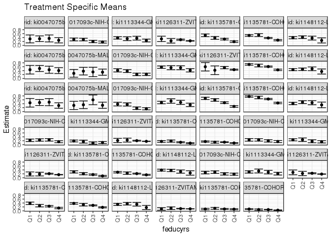

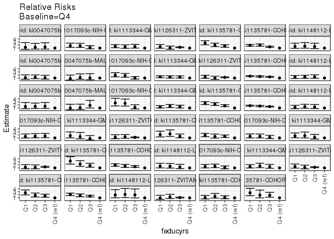

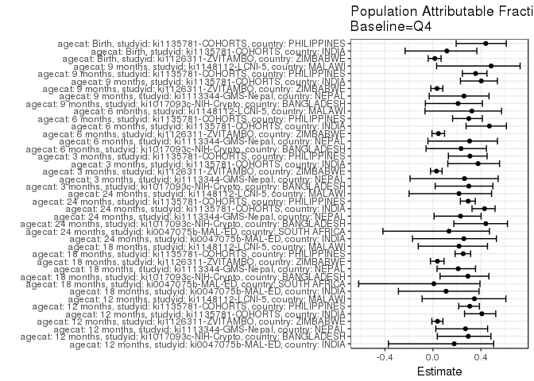

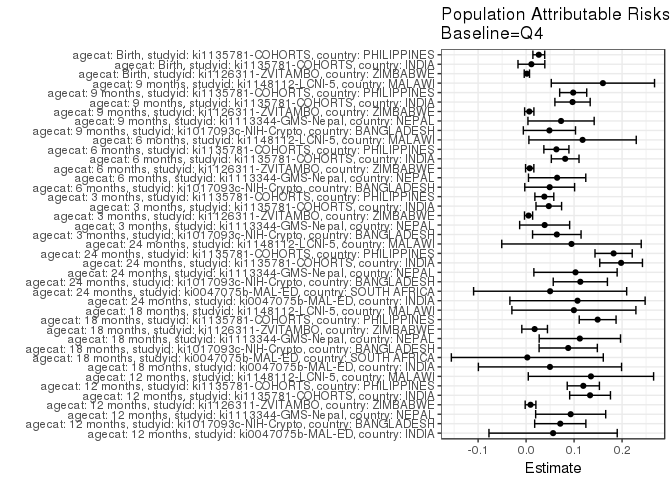

## Results Table

### Parameter: TSM

| agecat | studyid | country | intervention_level | baseline_level | estimate | ci_lower | ci_upper |
| --- | --- | --- | --- | --- | --- | --- | --- |
| Birth | ki1126311-ZVITAMBO | ZIMBABWE | Q4 | NA | 0.1013561 | 0.0958409 | 0.1068712 |
| Birth | ki1126311-ZVITAMBO | ZIMBABWE | Q1 | NA | 0.0975610 | 0.0333360 | 0.1617860 |
| Birth | ki1126311-ZVITAMBO | ZIMBABWE | Q2 | NA | 0.1340206 | 0.0662225 | 0.2018188 |
| Birth | ki1126311-ZVITAMBO | ZIMBABWE | Q3 | NA | 0.1119865 | 0.0973238 | 0.1266492 |
| Birth | ki1135781-COHORTS | INDIA | Q4 | NA | 0.0842105 | 0.0562788 | 0.1121423 |
| Birth | ki1135781-COHORTS | INDIA | Q1 | NA | 0.0909091 | 0.0546758 | 0.1271424 |
| Birth | ki1135781-COHORTS | INDIA | Q2 | NA | 0.1269036 | 0.0804046 | 0.1734025 |
| Birth | ki1135781-COHORTS | INDIA | Q3 | NA | 0.0934579 | 0.0687843 | 0.1181316 |
| Birth | ki1135781-COHORTS | PHILIPPINES | Q4 | NA | 0.0337349 | 0.0214500 | 0.0460199 |
| Birth | ki1135781-COHORTS | PHILIPPINES | Q1 | NA | 0.0898876 | 0.0674242 | 0.1123511 |
| Birth | ki1135781-COHORTS | PHILIPPINES | Q2 | NA | 0.0637255 | 0.0302006 | 0.0972503 |
| Birth | ki1135781-COHORTS | PHILIPPINES | Q3 | NA | 0.0625000 | 0.0488924 | 0.0761076 |
| 3 months | ki1017093c-NIH-Crypto | BANGLADESH | Q4 | NA | 0.1502591 | 0.0998125 | 0.2007056 |
| 3 months | ki1017093c-NIH-Crypto | BANGLADESH | Q1 | NA | 0.2248521 | 0.1618661 | 0.2878381 |
| 3 months | ki1017093c-NIH-Crypto | BANGLADESH | Q2 | NA | 0.2393617 | 0.1783260 | 0.3003974 |
| 3 months | ki1017093c-NIH-Crypto | BANGLADESH | Q3 | NA | 0.2471910 | 0.1837755 | 0.3106065 |
| 3 months | ki1113344-GMS-Nepal | NEPAL | Q4 | NA | 0.1086957 | 0.0567189 | 0.1606724 |
| 3 months | ki1113344-GMS-Nepal | NEPAL | Q1 | NA | 0.1895161 | 0.1406960 | 0.2383362 |
| 3 months | ki1113344-GMS-Nepal | NEPAL | Q2 | NA | 0.1555556 | 0.0806116 | 0.2304995 |
| 3 months | ki1113344-GMS-Nepal | NEPAL | Q3 | NA | 0.0851064 | 0.0286476 | 0.1415652 |
| 3 months | ki1126311-ZVITAMBO | ZIMBABWE | Q4 | NA | 0.1710336 | 0.1625649 | 0.1795023 |
| 3 months | ki1126311-ZVITAMBO | ZIMBABWE | Q1 | NA | 0.2142857 | 0.1068107 | 0.3217607 |
| 3 months | ki1126311-ZVITAMBO | ZIMBABWE | Q2 | NA | 0.2352941 | 0.1344685 | 0.3361197 |
| 3 months | ki1126311-ZVITAMBO | ZIMBABWE | Q3 | NA | 0.2038270 | 0.1810521 | 0.2266018 |
| 3 months | ki1135781-COHORTS | INDIA | Q4 | NA | 0.0786802 | 0.0520856 | 0.1052748 |
| 3 months | ki1135781-COHORTS | INDIA | Q1 | NA | 0.1646586 | 0.1185770 | 0.2107403 |
| 3 months | ki1135781-COHORTS | INDIA | Q2 | NA | 0.1850000 | 0.1311664 | 0.2388336 |
| 3 months | ki1135781-COHORTS | INDIA | Q3 | NA | 0.1209386 | 0.0937779 | 0.1480993 |
| 3 months | ki1135781-COHORTS | PHILIPPINES | Q4 | NA | 0.0852713 | 0.0655922 | 0.1049504 |
| 3 months | ki1135781-COHORTS | PHILIPPINES | Q1 | NA | 0.1607445 | 0.1311269 | 0.1903621 |

[output cut: 134 more lines]

### Parameter: E(Y)

| agecat | studyid | country | intervention_level | baseline_level | estimate | ci_lower | ci_upper |
| --- | --- | --- | --- | --- | --- | --- | --- |
| Birth | ki1126311-ZVITAMBO | ZIMBABWE | NA | NA | 0.1029718 | 0.1028961 | 0.1030475 |
| Birth | ki1135781-COHORTS | INDIA | NA | NA | 0.0952733 | 0.0945493 | 0.0959973 |
| Birth | ki1135781-COHORTS | PHILIPPINES | NA | NA | 0.0602158 | 0.0594875 | 0.0609441 |
| 3 months | ki1017093c-NIH-Crypto | BANGLADESH | NA | NA | 0.2142857 | 0.2114333 | 0.2171382 |
| 3 months | ki1113344-GMS-Nepal | NEPAL | NA | NA | 0.1473684 | 0.1438971 | 0.1508397 |
| 3 months | ki1126311-ZVITAMBO | ZIMBABWE | NA | NA | 0.1762134 | 0.1759499 | 0.1764770 |
| 3 months | ki1135781-COHORTS | INDIA | NA | NA | 0.1259843 | 0.1240170 | 0.1279515 |
| 3 months | ki1135781-COHORTS | PHILIPPINES | NA | NA | 0.1232978 | 0.1222803 | 0.1243152 |
| 6 months | ki1017093c-NIH-Crypto | BANGLADESH | NA | NA | 0.2097902 | 0.2071337 | 0.2124467 |
| 6 months | ki1113344-GMS-Nepal | NEPAL | NA | NA | 0.2117438 | 0.2079936 | 0.2154940 |
| 6 months | ki1126311-ZVITAMBO | ZIMBABWE | NA | NA | 0.1645789 | 0.1641842 | 0.1649737 |
| 6 months | ki1135781-COHORTS | INDIA | NA | NA | 0.1732852 | 0.1695831 | 0.1769873 |
| 6 months | ki1135781-COHORTS | PHILIPPINES | NA | NA | 0.2113885 | 0.2095488 | 0.2132281 |
| 6 months | ki1148112-LCNI-5 | MALAWI | NA | NA | 0.3633005 | 0.3605025 | 0.3660985 |
| 9 months | ki1017093c-NIH-Crypto | BANGLADESH | NA | NA | 0.2322946 | 0.2290196 | 0.2355696 |
| 9 months | ki1113344-GMS-Nepal | NEPAL | NA | NA | 0.2818182 | 0.2780432 | 0.2855932 |
| 9 months | ki1126311-ZVITAMBO | ZIMBABWE | NA | NA | 0.1944109 | 0.1940490 | 0.1947728 |
| 9 months | ki1135781-COHORTS | INDIA | NA | NA | 0.2404459 | 0.2360183 | 0.2448734 |
| 9 months | ki1135781-COHORTS | PHILIPPINES | NA | NA | 0.2760234 | 0.2732445 | 0.2788023 |
| 9 months | ki1148112-LCNI-5 | MALAWI | NA | NA | 0.3302752 | 0.3266968 | 0.3338536 |
| 12 months | ki0047075b-MAL-ED | INDIA | NA | NA | 0.3181818 | 0.3114736 | 0.3248901 |
| 12 months | ki1017093c-NIH-Crypto | BANGLADESH | NA | NA | 0.2422096 | 0.2377638 | 0.2466554 |
| 12 months | ki1113344-GMS-Nepal | NEPAL | NA | NA | 0.3429084 | 0.3383684 | 0.3474485 |
| 12 months | ki1126311-ZVITAMBO | ZIMBABWE | NA | NA | 0.2423271 | 0.2417866 | 0.2428676 |
| 12 months | ki1135781-COHORTS | INDIA | NA | NA | 0.3274262 | 0.3212478 | 0.3336046 |
| 12 months | ki1135781-COHORTS | PHILIPPINES | NA | NA | 0.3890478 | 0.3853681 | 0.3927276 |
| 12 months | ki1148112-LCNI-5 | MALAWI | NA | NA | 0.3909532 | 0.3877858 | 0.3941205 |
| 18 months | ki0047075b-MAL-ED | INDIA | NA | NA | 0.4545455 | 0.4472147 | 0.4618763 |
| 18 months | ki0047075b-MAL-ED | SOUTH AFRICA | NA | NA | 0.3260870 | 0.3182553 | 0.3339186 |
| 18 months | ki1017093c-NIH-Crypto | BANGLADESH | NA | NA | 0.3012618 | 0.2939542 | 0.3085694 |
| 18 months | ki1113344-GMS-Nepal | NEPAL | NA | NA | 0.5318761 | 0.5265149 | 0.5372374 |
| 18 months | ki1126311-ZVITAMBO | ZIMBABWE | NA | NA | 0.4704449 | 0.4684826 | 0.4724071 |
| 18 months | ki1135781-COHORTS | PHILIPPINES | NA | NA | 0.5915074 | 0.5874274 | 0.5955875 |
| 18 months | ki1148112-LCNI-5 | MALAWI | NA | NA | 0.4581006 | 0.4557692 | 0.4604319 |
| 24 months | ki0047075b-MAL-ED | INDIA | NA | NA | 0.4166667 | 0.4040139 | 0.4293194 |
| 24 months | ki0047075b-MAL-ED | SOUTH AFRICA | NA | NA | 0.3736264 | 0.3527085 | 0.3945442 |
| 24 months | ki1017093c-NIH-Crypto | BANGLADESH | NA | NA | 0.2568093 | 0.2474294 | 0.2661893 |
| 24 months | ki1113344-GMS-Nepal | NEPAL | NA | NA | 0.4477912 | 0.4422812 | 0.4533011 |
| 24 months | ki1135781-COHORTS | INDIA | NA | NA | 0.4608696 | 0.4530832 | 0.4686559 |
| 24 months | ki1135781-COHORTS | PHILIPPINES | NA | NA | 0.6214347 | 0.6163971 | 0.6264724 |
| 24 months | ki1148112-LCNI-5 | MALAWI | NA | NA | 0.4360771 | 0.4328027 | 0.4393514 |

### Parameter: RR

| agecat | studyid | country | intervention_level | baseline_level | estimate | ci_lower | ci_upper |
| --- | --- | --- | --- | --- | --- | --- | --- |
| Birth | ki1126311-ZVITAMBO | ZIMBABWE | Q4 | Q4 | 1.0000000 | 1.0000000 | 1.000000 |
| Birth | ki1126311-ZVITAMBO | ZIMBABWE | Q1 | Q4 | 0.9625570 | 0.4972246 | 1.863375 |
| Birth | ki1126311-ZVITAMBO | ZIMBABWE | Q2 | Q4 | 1.3222755 | 0.7949766 | 2.199326 |
| Birth | ki1126311-ZVITAMBO | ZIMBABWE | Q3 | Q4 | 1.1048822 | 0.9588214 | 1.273193 |
| Birth | ki1135781-COHORTS | INDIA | Q4 | Q4 | 1.0000000 | 1.0000000 | 1.000000 |
| Birth | ki1135781-COHORTS | INDIA | Q1 | Q4 | 1.0795455 | 0.6427563 | 1.813157 |
| Birth | ki1135781-COHORTS | INDIA | Q2 | Q4 | 1.5069797 | 0.9193073 | 2.470325 |
| Birth | ki1135781-COHORTS | INDIA | Q3 | Q4 | 1.1098131 | 0.7263378 | 1.695747 |
| Birth | ki1135781-COHORTS | PHILIPPINES | Q4 | Q4 | 1.0000000 | 1.0000000 | 1.000000 |
| Birth | ki1135781-COHORTS | PHILIPPINES | Q1 | Q4 | 2.6645265 | 1.7132011 | 4.144114 |
| Birth | ki1135781-COHORTS | PHILIPPINES | Q2 | Q4 | 1.8890056 | 0.9962332 | 3.581834 |
| Birth | ki1135781-COHORTS | PHILIPPINES | Q3 | Q4 | 1.8526786 | 1.2120945 | 2.831807 |
| 3 months | ki1017093c-NIH-Crypto | BANGLADESH | Q4 | Q4 | 1.0000000 | 1.0000000 | 1.000000 |
| 3 months | ki1017093c-NIH-Crypto | BANGLADESH | Q1 | Q4 | 1.4964293 | 0.9664137 | 2.317124 |
| 3 months | ki1017093c-NIH-Crypto | BANGLADESH | Q2 | Q4 | 1.5929934 | 1.0450100 | 2.428329 |
| 3 months | ki1017093c-NIH-Crypto | BANGLADESH | Q3 | Q4 | 1.6450988 | 1.0781777 | 2.510115 |
| 3 months | ki1113344-GMS-Nepal | NEPAL | Q4 | Q4 | 1.0000000 | 1.0000000 | 1.000000 |
| 3 months | ki1113344-GMS-Nepal | NEPAL | Q1 | Q4 | 1.7435484 | 1.0128452 | 3.001407 |
| 3 months | ki1113344-GMS-Nepal | NEPAL | Q2 | Q4 | 1.4311111 | 0.7258922 | 2.821464 |
| 3 months | ki1113344-GMS-Nepal | NEPAL | Q3 | Q4 | 0.7829787 | 0.3456181 | 1.773795 |
| 3 months | ki1126311-ZVITAMBO | ZIMBABWE | Q4 | Q4 | 1.0000000 | 1.0000000 | 1.000000 |
| 3 months | ki1126311-ZVITAMBO | ZIMBABWE | Q1 | Q4 | 1.2528868 | 0.7568897 | 2.073916 |
| 3 months | ki1126311-ZVITAMBO | ZIMBABWE | Q2 | Q4 | 1.3757189 | 0.8937014 | 2.117712 |
| 3 months | ki1126311-ZVITAMBO | ZIMBABWE | Q3 | Q4 | 1.1917365 | 1.0546362 | 1.346660 |
| 3 months | ki1135781-COHORTS | INDIA | Q4 | Q4 | 1.0000000 | 1.0000000 | 1.000000 |
| 3 months | ki1135781-COHORTS | INDIA | Q1 | Q4 | 2.0927581 | 1.3493891 | 3.245644 |
| 3 months | ki1135781-COHORTS | INDIA | Q2 | Q4 | 2.3512903 | 1.5052403 | 3.672880 |
| 3 months | ki1135781-COHORTS | INDIA | Q3 | Q4 | 1.5370910 | 1.0243671 | 2.306447 |
| 3 months | ki1135781-COHORTS | PHILIPPINES | Q4 | Q4 | 1.0000000 | 1.0000000 | 1.000000 |
| 3 months | ki1135781-COHORTS | PHILIPPINES | Q1 | Q4 | 1.8850946 | 1.4030742 | 2.532711 |

[output cut: 134 more lines]

### Parameter: PAR

| agecat | studyid | country | intervention_level | baseline_level | estimate | ci_lower | ci_upper |
| --- | --- | --- | --- | --- | --- | --- | --- |
| Birth | ki1126311-ZVITAMBO | ZIMBABWE | Q4 | NA | 0.0016157 | -0.0039000 | 0.0071314 |
| Birth | ki1135781-COHORTS | INDIA | Q4 | NA | 0.0110627 | -0.0168784 | 0.0390038 |
| Birth | ki1135781-COHORTS | PHILIPPINES | Q4 | NA | 0.0264809 | 0.0141744 | 0.0387874 |
| 3 months | ki1017093c-NIH-Crypto | BANGLADESH | Q4 | NA | 0.0640266 | 0.0134995 | 0.1145538 |
| 3 months | ki1113344-GMS-Nepal | NEPAL | Q4 | NA | 0.0386728 | -0.0134197 | 0.0907653 |
| 3 months | ki1126311-ZVITAMBO | ZIMBABWE | Q4 | NA | 0.0051799 | -0.0032930 | 0.0136527 |
| 3 months | ki1135781-COHORTS | INDIA | Q4 | NA | 0.0473040 | 0.0206368 | 0.0739713 |
| 3 months | ki1135781-COHORTS | PHILIPPINES | Q4 | NA | 0.0380264 | 0.0183211 | 0.0577318 |
| 6 months | ki1017093c-NIH-Crypto | BANGLADESH | Q4 | NA | 0.0491684 | -0.0027383 | 0.1010752 |
| 6 months | ki1113344-GMS-Nepal | NEPAL | Q4 | NA | 0.0646849 | 0.0049912 | 0.1243787 |
| 6 months | ki1126311-ZVITAMBO | ZIMBABWE | Q4 | NA | 0.0075445 | -0.0010798 | 0.0161688 |
| 6 months | ki1135781-COHORTS | INDIA | Q4 | NA | 0.0814485 | 0.0526108 | 0.1102862 |
| 6 months | ki1135781-COHORTS | PHILIPPINES | Q4 | NA | 0.0631367 | 0.0370202 | 0.0892532 |
| 6 months | ki1148112-LCNI-5 | MALAWI | Q4 | NA | 0.1176865 | 0.0058360 | 0.2295369 |
| 9 months | ki1017093c-NIH-Crypto | BANGLADESH | Q4 | NA | 0.0486211 | -0.0057255 | 0.1029678 |
| 9 months | ki1113344-GMS-Nepal | NEPAL | Q4 | NA | 0.0728630 | 0.0038598 | 0.1418661 |
| 9 months | ki1126311-ZVITAMBO | ZIMBABWE | Q4 | NA | 0.0066227 | -0.0030370 | 0.0162823 |
| 9 months | ki1135781-COHORTS | INDIA | Q4 | NA | 0.0967839 | 0.0600157 | 0.1335521 |
| 9 months | ki1135781-COHORTS | PHILIPPINES | Q4 | NA | 0.0981522 | 0.0699602 | 0.1263443 |
| 9 months | ki1148112-LCNI-5 | MALAWI | Q4 | NA | 0.1600625 | 0.0524776 | 0.2676473 |
| 12 months | ki0047075b-MAL-ED | INDIA | Q4 | NA | 0.0562771 | -0.0773672 | 0.1899214 |
| 12 months | ki1017093c-NIH-Crypto | BANGLADESH | Q4 | NA | 0.0712252 | 0.0178855 | 0.1245649 |
| 12 months | ki1113344-GMS-Nepal | NEPAL | Q4 | NA | 0.0929084 | 0.0199272 | 0.1658897 |
| 12 months | ki1126311-ZVITAMBO | ZIMBABWE | Q4 | NA | 0.0092593 | -0.0019057 | 0.0204244 |
| 12 months | ki1135781-COHORTS | INDIA | Q4 | NA | 0.1333085 | 0.0907980 | 0.1758190 |
| 12 months | ki1135781-COHORTS | PHILIPPINES | Q4 | NA | 0.1192531 | 0.0857321 | 0.1527741 |
| 12 months | ki1148112-LCNI-5 | MALAWI | Q4 | NA | 0.1351392 | 0.0045835 | 0.2656948 |
| 18 months | ki0047075b-MAL-ED | INDIA | Q4 | NA | 0.0497835 | -0.0994082 | 0.1989753 |
| 18 months | ki0047075b-MAL-ED | SOUTH AFRICA | Q4 | NA | 0.0025575 | -0.1557477 | 0.1608628 |
| 18 months | ki1017093c-NIH-Crypto | BANGLADESH | Q4 | NA | 0.0877787 | 0.0270927 | 0.1484647 |
| 18 months | ki1113344-GMS-Nepal | NEPAL | Q4 | NA | 0.1120288 | 0.0272679 | 0.1967897 |
| 18 months | ki1126311-ZVITAMBO | ZIMBABWE | Q4 | NA | 0.0177976 | -0.0089235 | 0.0445186 |
| 18 months | ki1135781-COHORTS | PHILIPPINES | Q4 | NA | 0.1491111 | 0.1107327 | 0.1874895 |
| 18 months | ki1148112-LCNI-5 | MALAWI | Q4 | NA | 0.0996100 | -0.0296085 | 0.2288285 |
| 24 months | ki0047075b-MAL-ED | INDIA | Q4 | NA | 0.1071429 | -0.0337711 | 0.2480568 |
| 24 months | ki0047075b-MAL-ED | SOUTH AFRICA | Q4 | NA | 0.0500970 | -0.1094016 | 0.2095955 |
| 24 months | ki1017093c-NIH-Crypto | BANGLADESH | Q4 | NA | 0.1130185 | 0.0565815 | 0.1694554 |
| 24 months | ki1113344-GMS-Nepal | NEPAL | Q4 | NA | 0.1029636 | 0.0162051 | 0.1897221 |
| 24 months | ki1135781-COHORTS | INDIA | Q4 | NA | 0.1979830 | 0.1534797 | 0.2424863 |
| 24 months | ki1135781-COHORTS | PHILIPPINES | Q4 | NA | 0.1823722 | 0.1435870 | 0.2211575 |
| 24 months | ki1148112-LCNI-5 | MALAWI | Q4 | NA | 0.0946136 | -0.0507009 | 0.2399282 |

### Parameter: PAF

| agecat | studyid | country | intervention_level | baseline_level | estimate | ci_lower | ci_upper |
| --- | --- | --- | --- | --- | --- | --- | --- |
| Birth | ki1126311-ZVITAMBO | ZIMBABWE | Q4 | NA | 0.0156909 | -0.0393582 | 0.0678244 |
| Birth | ki1135781-COHORTS | INDIA | Q4 | NA | 0.1161159 | -0.2316404 | 0.3656824 |
| Birth | ki1135781-COHORTS | PHILIPPINES | Q4 | NA | 0.4397660 | 0.1934904 | 0.6108390 |
| 3 months | ki1017093c-NIH-Crypto | BANGLADESH | Q4 | NA | 0.2987910 | 0.0187765 | 0.4988970 |
| 3 months | ki1113344-GMS-Nepal | NEPAL | Q4 | NA | 0.2624224 | -0.1905100 | 0.5430355 |
| 3 months | ki1126311-ZVITAMBO | ZIMBABWE | Q4 | NA | 0.0293953 | -0.0198968 | 0.0763052 |
| 3 months | ki1135781-COHORTS | INDIA | Q4 | NA | 0.3754759 | 0.1240061 | 0.5547568 |
| 3 months | ki1135781-COHORTS | PHILIPPINES | Q4 | NA | 0.3084114 | 0.1287571 | 0.4510202 |
| 6 months | ki1017093c-NIH-Crypto | BANGLADESH | Q4 | NA | 0.2343696 | -0.0575242 | 0.4456960 |
| 6 months | ki1113344-GMS-Nepal | NEPAL | Q4 | NA | 0.3054869 | -0.0418091 | 0.5370088 |
| 6 months | ki1126311-ZVITAMBO | ZIMBABWE | Q4 | NA | 0.0458412 | -0.0080215 | 0.0968258 |
| 6 months | ki1135781-COHORTS | INDIA | Q4 | NA | 0.4700255 | 0.2758684 | 0.6121244 |
| 6 months | ki1135781-COHORTS | PHILIPPINES | Q4 | NA | 0.2986762 | 0.1637641 | 0.4118227 |
| 6 months | ki1148112-LCNI-5 | MALAWI | Q4 | NA | 0.3239370 | -0.0659268 | 0.5712077 |
| 9 months | ki1017093c-NIH-Crypto | BANGLADESH | Q4 | NA | 0.2093081 | -0.0627279 | 0.4117086 |
| 9 months | ki1113344-GMS-Nepal | NEPAL | Q4 | NA | 0.2585460 | -0.0313459 | 0.4669547 |
| 9 months | ki1126311-ZVITAMBO | ZIMBABWE | Q4 | NA | 0.0340652 | -0.0169191 | 0.0824934 |
| 9 months | ki1135781-COHORTS | INDIA | Q4 | NA | 0.4025184 | 0.2291738 | 0.5368810 |
| 9 months | ki1135781-COHORTS | PHILIPPINES | Q4 | NA | 0.3555939 | 0.2452586 | 0.4497994 |
| 9 months | ki1148112-LCNI-5 | MALAWI | Q4 | NA | 0.4846336 | 0.0305950 | 0.7260149 |
| 12 months | ki0047075b-MAL-ED | INDIA | Q4 | NA | 0.1768707 | -0.3708471 | 0.5057496 |
| 12 months | ki1017093c-NIH-Crypto | BANGLADESH | Q4 | NA | 0.2940642 | 0.0361489 | 0.4829643 |
| 12 months | ki1113344-GMS-Nepal | NEPAL | Q4 | NA | 0.2709424 | 0.0240483 | 0.4553778 |
| 12 months | ki1126311-ZVITAMBO | ZIMBABWE | Q4 | NA | 0.0382101 | -0.0089815 | 0.0831945 |
| 12 months | ki1135781-COHORTS | INDIA | Q4 | NA | 0.4071407 | 0.2631049 | 0.5230228 |
| 12 months | ki1135781-COHORTS | PHILIPPINES | Q4 | NA | 0.3065255 | 0.2150882 | 0.3873110 |
| 12 months | ki1148112-LCNI-5 | MALAWI | Q4 | NA | 0.3456660 | -0.0899488 | 0.6071806 |
| 18 months | ki0047075b-MAL-ED | INDIA | Q4 | NA | 0.1095238 | -0.2872400 | 0.3839938 |
| 18 months | ki0047075b-MAL-ED | SOUTH AFRICA | Q4 | NA | 0.0078431 | -0.6183769 | 0.3917515 |
| 18 months | ki1017093c-NIH-Crypto | BANGLADESH | Q4 | NA | 0.2913701 | 0.0593497 | 0.4661604 |
| 18 months | ki1113344-GMS-Nepal | NEPAL | Q4 | NA | 0.2106295 | 0.0341886 | 0.3548370 |
| 18 months | ki1126311-ZVITAMBO | ZIMBABWE | Q4 | NA | 0.0378314 | -0.0206661 | 0.0929762 |
| 18 months | ki1135781-COHORTS | PHILIPPINES | Q4 | NA | 0.2520866 | 0.1844832 | 0.3140860 |
| 18 months | ki1148112-LCNI-5 | MALAWI | Q4 | NA | 0.2174413 | -0.1221455 | 0.4542615 |
| 24 months | ki0047075b-MAL-ED | INDIA | Q4 | NA | 0.2571429 | -0.1702129 | 0.5284305 |
| 24 months | ki0047075b-MAL-ED | SOUTH AFRICA | Q4 | NA | 0.1340830 | -0.4161861 | 0.4705412 |
| 24 months | ki1017093c-NIH-Crypto | BANGLADESH | Q4 | NA | 0.4400871 | 0.1740492 | 0.6204345 |
| 24 months | ki1113344-GMS-Nepal | NEPAL | Q4 | NA | 0.2299366 | 0.0098407 | 0.4011089 |
| 24 months | ki1135781-COHORTS | INDIA | Q4 | NA | 0.4295857 | 0.3255532 | 0.5175713 |
| 24 months | ki1135781-COHORTS | PHILIPPINES | Q4 | NA | 0.2934697 | 0.2285061 | 0.3529630 |
| 24 months | ki1148112-LCNI-5 | MALAWI | Q4 | NA | 0.2169654 | -0.1983479 | 0.4883429 |